# STATS 315B - Homework 2

Rachael Caelie (Rocky) Aikens, Christine Tataru, and Daniel Sosa

May 14, 2018

## TODO:

- [] Check 3
- [] Check 4
- [] Figure out how to set weights such that false positive rate is low
- []

# Problem 1:

**(10) Random forests predict with an ensemble of bagged trees each trained on a bootstrap sample randomly drawn from the original training data. Additional random variation among the trees is induced by choosing the variable for each split from a small randomly chosen subset of all of the predictor variables when building each tree. What are the advantages and disadvantages of this random variable selection strategy? How can one introduce additional tree variation in the forest without randomly selecting subsets of variables?**

*Advantages:* Without the random variable selection strategy, the trees from the bootstrapped samples are likely to be highly correllated: Since the input samples are very similar, the trees may tend to split on the same subset of highly correllated variables. However, averaging a forest of near-identical trees adds little value when it comes to decreasing the variance of the overall classifier. The random variable selection strategy introduces variation among the trees by ensuring that they are not all splitting on the same sequence of variables. This breaks down the correllations between trees in the forest.

*Disadvantages:* Suppose (as is very often the case), that many of the model variables are uninformative for prediction. In this case, the random variable selection strategy is likely to generate many trees which have splits on relatively useless variables.

Additional variation can be induced by: - limiting the sample sizes from which each base learner is trained. - during training, using random split points for each feature under consideration when constructing a split, rather than the optimal split point for each feature (as in the ExtraTrees approach).

# Problem 2:

**(5) Why is it necessary to use regularization in linear regression when the number of predictor variables is greater than the number of observations in the training sample? Explain how regularization helps in this case. Are there other situations where regularization might help? What is the potential disadvantage of introducing regularization? Why is sparsity a reasonable assumption in the boosting context. Is it always? If not, why not?**

We showed in 315A that, when $n < p$, there is an infinite number of equally optimal solutions to the linear least squares problem. In these cases, all of those optimal solutions are likely to be highly overfit to the training data. Regularization helps us simplify the linear model we produce (decrease model variance), and allows us to select for models which are in line with our expectations (i.e. sparse ones) by adding a “prior” for our coefficients. This same logic applies when $n \geq p$, but $p$ is very large, and/or many of our variables are uninformative.

However, introducing regularization adds bias to our model: too much regularization can be just as bad for performance as too little. At the extreme, putting infinite weight on the regularization in our model training results in a model with all coefficients equal to zero, which is useless.

In the boosting context, the “predictor variables” for our linear regression are the results from all possible base learners. However, almost all base learners are probably very poor predictors of the outcome; only a small subset of them are effective and should have nonzero weight. This means we generally want a sparse model. This assumption might not hold true if we happened to be dealing with a small base learner function class in which nearly all models were effective predictors. However, in practice, this nearly never happens.

# Problem 3:

**(15) Assume squared error loss. Show that the convex members of the power family of penalties, except for the lasso, have the property that solutions for $\lambda > 0$ have nonzero values for all coefficients at each path point.**

3a. Power family produces dense solutions:

We first consider the general minimum found by setting the derivative with respect to $a_j$ to 0.
$$\frac{d}{da_j} \hat{R}(a) + \lambda P(a) = \frac{d}{da_j} ((y - xa)^2 + \sum_{k}^K a_k^{\gamma}) = -2x_j(y - xa) + \gamma a_j^{\gamma - 1} = 0$$
2) assume toward contradiction that a_j = 0
$$-2x_j(y - xa) = 0$$
3) Contradiction. The probability of $y - xa = 0$ is 0 for some continuous y. Therefore, the likelihood of $a_j$ being exactly equal to 0 is very low.

3b: Elastic net produces sparse solutions: The elastic net takes the general form
$$(y-xa)^2 + \sum_{j=1}^n (\gamma - 1)a_j^2/2 + (2-\gamma)|a_j|$$

We would like to take the derivative w.r.t $a_j$ as we did above, however, we cannot differentiate the absolute value. We therefore take directional derivatives. As before, we assume $a_j = 0$ and that $a_j$ is a minimum. For this to be true, the derivatives with respect to $a_j$ in every direction must be greater than 0

Assume without loss of generality that we move in the cardinal direction $e_1 = [1, 0, 0,...]$
$$D_{e_1} = lim_{\epsilon -> 0} \frac{1}{\epsilon} [ R(a + \epsilon e_1) - R(a) + \lambda P(a + \epsilon e_{1}) - \lambda P(a)]$$

As we can expressly take the derivative of the risk component, we can easily see:
$$R(a + \epsilon e_j) - R(a) = 2 \epsilon e_1 x_j(y - x(a))$$

We then consider the penalty component
$$\lambda P(a_j + \epsilon e_1) - \lambda P(a_j) = \frac{\lambda}{2} (\gamma - 1) (a_j + \epsilon e_1)^2 + \lambda (2 - \gamma)|a_j + \epsilon e_1| -\frac{\lambda}{2}(\gamma - 1) a_j^2 - \lambda (2 - \gamma)|a_j| =$$

We have assumed that $a_j = 0$
$$\lambda P(a_j + \epsilon e_1) - \lambda P(a_j) = \frac{\lambda }{2}(\gamma - 1) (\epsilon e_1)^2 + \lambda(2 - \gamma) |\epsilon e_1|$$
Putting these components together, we mandate that the derivative must be greater than 0:
$$2 \epsilon e_1 x_j(y - x(a)) + \frac{\lambda}{2} (\gamma - 1) (\epsilon e_1)^2 + \lambda(2 - \gamma) |\epsilon e_1| > 0$$
Simplifying, we find:
$$x_j(y - x(a)) > - \frac{\lambda}{4} (\gamma - 1) \epsilon e_1 - \frac{\lambda}{2}(2 - \gamma)$$
We then perform the same process moving in the cardinal direction $e_{-1} = [-1,0,0,...]$ and find:
$$x_j(y - x(a)) < - \frac{\lambda}{4} (\gamma - 1) \epsilon e_{-1} - \frac{\lambda}{2}(2 - \gamma)$$
In contrast to the power family penalty, the elastic net penalty allows a range of values for the values of $(y - x(a))$. This range is parameterized by $\lambda$ adn $\gamma$. This means that the probability of any coefficient $a_j$ having a minimum of 0 for any $\lambda$ is much (infinitely?) higher than it was for the power family.

# Problem 4:

$$j^* = argmin_{1 \leq j \leq J} min_{\rho} E[y - \rho x_j]^2$$
First, we find an expression for $\rho^*(j)$, the $\rho$ that minimizes the expression for any given j. Take the derivative w.r.t $\rho$ and set the expression to 0:
$$\frac{1}{n} \sum_{i=1}^N (y_i - \rho x_{ij})^2$$

$$\frac{1}{n} \sum_{i=1}^N -2 x_{ij}(y_i - \rho x_{ij})$$
$$\frac{2}{n} \rho \sum_i x_{ij}^2 = \frac{2}{n} \sum_{i} x_{ij} y_i$$

$$\rho = \frac{\sum_i x_{ij} y_i}{ \sum_i x_{ij}^2}$$
$$\rho^*(j) = \frac{ E[y x_j]} { E[x_{j^2}]}$$
We can now plug this back into the original expression to try to minimize over j:
$$j^* = argmin_j \frac{1}{n} \sum_i (y_i - \frac{ E[y x_j]} { E[x_{j^2}]} x_{ij})^2$$
From this, we can easily see that the argument j that minimizes the above expression is the same as the j that maximizes $E[y x_j]$

# Problem 5:

The partial dependence of F(x) on $z_l$ can be expressed as the expectation of F(x) after integrating over all values $z_{\l}$
$$E_{z \l}[F(x)] = \int F(x) f_{z \l}(t) dt$$
Expanding F(x):
$$\int F_l(z_l) f_{z \l}(t) dt + \int F_{z \l}(t) f_{z \l}(t) dt$$
Simplifying, we find
$$F_l(z_l) * 1 + \int F_{z \l}(t) f_{z \l}(t) dt$$
It can be seen that the second term is a function integrated over it’s entire domain, which will result in some constant c.
$$E_{z \l}[F(x)] = F_l(z_l) + c$$
We now consider the dependence of F(x) on $z_l$ ignoring the other variables
$$\begin{aligned}
E[F(x) | z_l] = \int F(x) f_{z\l | z_l}
\end{aligned}$$

$$E[F(x) | z_l] = \int F(x) f_{z\l | z_l}$$
$$= \int F_l(z_l) f_{z\l | z_l}(t)dt + \int F_{\l}(t)f_{z\l | z_l}(t)dt$$
$$F_l(z_l) * 1 + \int F_{\l}(t)f_{z\l | z_l}(t)dt$$
Unlike in the previous case, the second term does NOT integrate to a constant, because the probability density $f_{z\l | z_l}(t)$ depends on the given value of $z_l$

$$F_l(z_l) + \int F_{\l}(t)f_{z\l | z_l}(t)dt$$
If the values of $z_{\l}$ are completely independent of $z_l$, the two methods will be identical.

```r
#setwd("~/Desktop/Stats315B/Stat315b/HW2")
require(gbm)
spam_train <- read.csv("spam_stats315B_train.csv", header=F)
spam_test <- read.csv("spam_stats315B_test.csv", header=F)
rflabs<-c("make", "address", "all", "3d", "our", "over", "remove",
  "internet","order", "mail", "receive", "will",
  "people", "report", "addresses","free", "business",
  "email", "you", "credit", "your", "font","000","money",
  "hp", "hpl", "george", "650", "lab", "labs",
  "telnet", "857", "data", "415", "85", "technology", "1999",
  "parts","pm", "direct", "cs", "meeting", "original", "project",
  "re","edu", "table", "conference", "semicolon", "left_bracket_round", "left_bracket_square", "exclaim", "dollar", "pound",
  "CAPAVE", "CAPMAX", "CAPTOT","type")
  # Names for predictors and response
colnames(spam_train) <- colnames(spam_test) <- rflabs

#normalize all columns by mean and variance
type = spam_train$type
spam_train <- data.frame(apply(select(spam_train, -type), 2, function(vec) return((vec - mean(vec)) / sd(vec))))
spam_train$type = type

type = spam_test$type
spam_test <- data.frame(apply(select(spam_test, -type), 2, function(vec) return((vec - mean(vec)) / sd(vec))))
spam_test$type = type


train_gbm <- function(weights = NULL, shrinkage = .008, depth = 6){
  gbm0 <- gbm(type ~ ., data=spam_train, train.fraction=0.8, interaction.depth= depth, shrinkage = shrinkage, n.trees= 4000, bag.fraction=0.7, cv.folds=5, distribution="bernoulli", verbose=F)
  best_iter <- gbm.perf(gbm0, method="cv")
  imp <- summary(gbm0, main="RELATIVE INFLUENCE OF ALL PREDICTORS")

  gbm0.test <- predict(gbm0, spam_test, type="response", n.trees= best_iter)
  gbm0.labels <- as.numeric(gbm0.test >= 0.5)
  (misclassification.error <- sum(spam_test$type != gbm0.labels) / nrow(spam_test)*100)
  test.pos.inds <- which(spam_test$type == 1)
  test.neg.inds <- which(spam_test$type == 0)
  (false.negs <- sum(spam_test[test.pos.inds,]$type != gbm0.labels[test.pos.inds]) / length(test.pos.inds)*100)
  (false.pos <- sum(spam_test[test.neg.inds,]$type != gbm0.labels[test.neg.inds]) / length(test.neg.inds)*100)

  return(list(imp = imp, labels = gbm0.labels, misclass = misclassification.error, false.negs = false.negs, false.pos = false.pos, model = gbm0 ))
}

#for(depth in c(2,3,4,5,6)){
#  for(shrink in c(.001, .005,  .01, .05, .08)){
    shrink = .008
    depth = 6
    res = train_gbm(shrinkage = shrink, depth = depth)
```

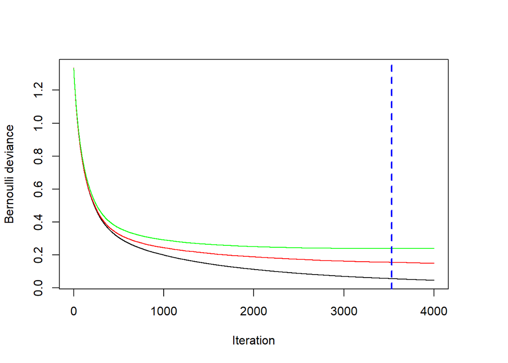

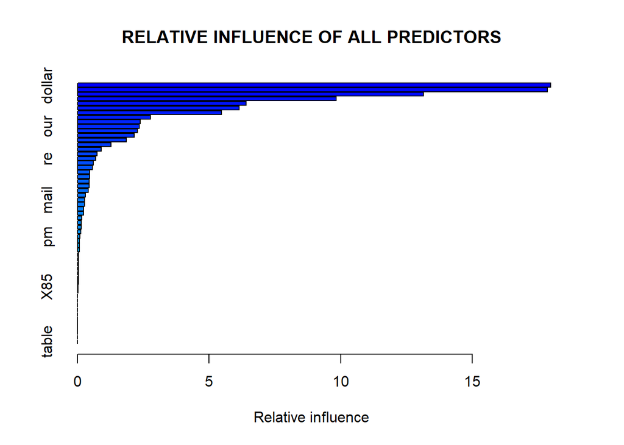

```r
    print(paste("Shrink: ", shrink, " interaction depth: ", depth))
```

```
## [1] "Shrink:  0.008  interaction depth:  6"
```

```r
    print(paste("misclassification: ", res$misclass))
```

```
## [1] "misclassification:  3.71577574967405"
```

```r
#  }
#}
#found a minimum of cross-validation accuracy at shrink of .008 and interaction depth of 6


#3.8% false positives (good emails classified as spam)
```

**(a) Based on the training data, fit a gbm model for predicting whether or not an email is spam , following the example in the tutorial. What is your estimate of the misclassification rate? Of all the spam emails of the test set what percentage was misclassified, and of all the non-spam emails in the test set what percentage was misclassified?**

Misclassification error: 3.7157757 Spam misclassified as non-spam (false neg): 3.3980583 Non-spam misclassified as spam (false pos): 3.930131

**(b) Your classifier in part (a) can be used as a spam filter. One of the possible disadvantages of such a spam filter is that it might filter out too many good (non-spam) emails. Therefore, a better spam filter might be the one that penalizes misclassifying non-spam emails more heavily than the spam ones. Suppose that you want to build a spam filter that throws out no more that 0.3% of the good (non-spam) emails. You have to find and use a cost matrix that penalizes misclassifying good emails as spam more than misclassifying spam emails as good by the method of trial and error. Once you have constructed your final spam filter with the property described above, answer the following questions:**

```r
weights = ifelse(spam_train$type == 0, 100000000000000000000000000000000000, 1)
res_weighted = train_gbm(weights = weights)
```

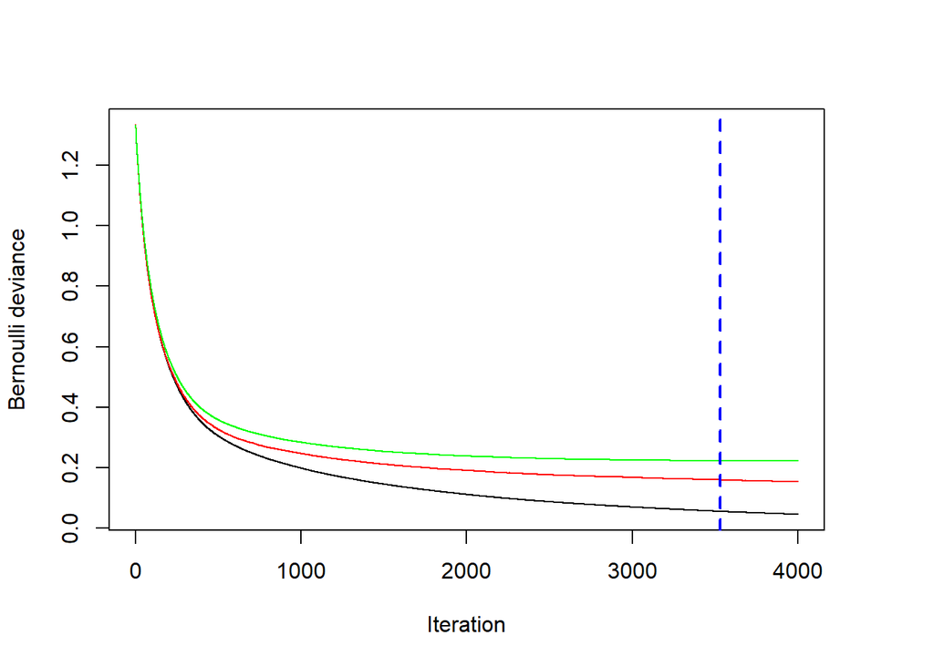

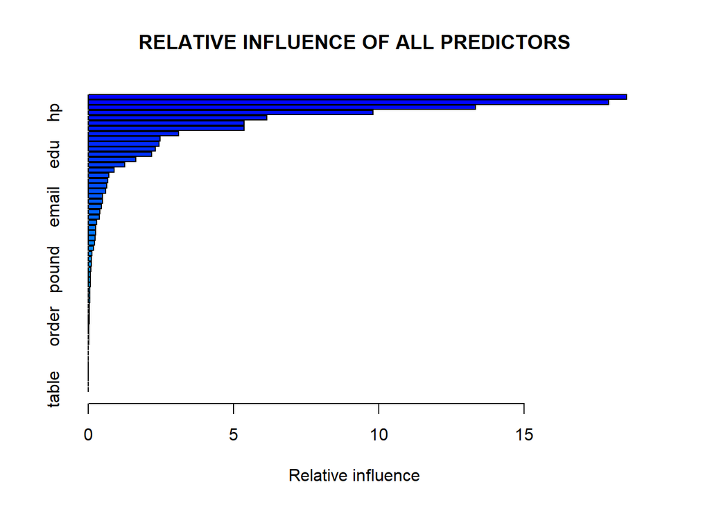

```r
print(res_weighted$false.pos)
```

```
## [1] 4.039301
```

*(ii) What are the important variables in discriminating good emails from spam for your spamfilter?*

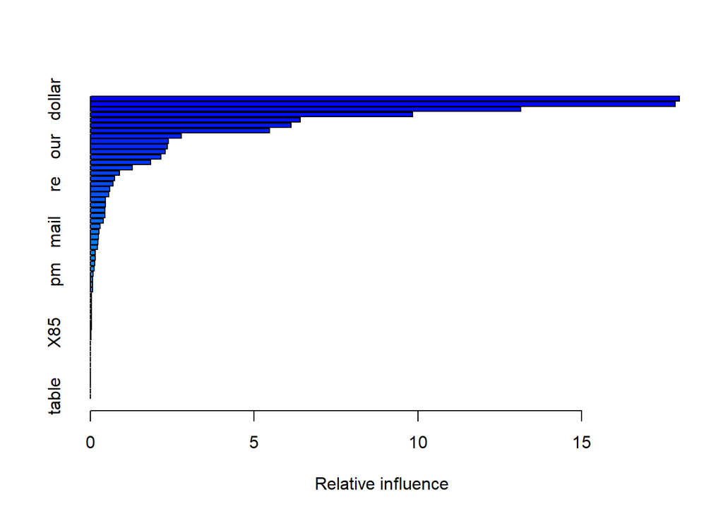

```
##                                     var      rel.inf
## dollar                           dollar 1.798772e+01
## exclaim                         exclaim 1.786390e+01
## remove                           remove 1.314735e+01
## hp                                   hp 9.835647e+00
## your                               your 6.409807e+00
## free                               free 6.133413e+00
## CAPAVE                           CAPAVE 5.464906e+00
## CAPMAX                           CAPMAX 2.777102e+00
## money                             money 2.382709e+00
## our                                 our 2.349172e+00
## edu                                 edu 2.280514e+00
## CAPTOT                           CAPTOT 2.152991e+00
## george                           george 1.845459e+00
## you                                 you 1.276636e+00
## X000                               X000 8.932094e-01
## will                               will 7.417900e-01
## re                                   re 6.838227e-01
## business                       business 5.977998e-01
## left_bracket_round   left_bracket_round 5.597697e-01
## X650                               X650 4.642998e-01
## semicolon                     semicolon 4.597414e-01
## email                             email 4.388514e-01
## X1999                             X1999 4.372929e-01
## receive                         receive 4.010354e-01
## meeting                         meeting 3.042173e-01
## mail                               mail 2.593138e-01
## over                               over 2.561043e-01
## technology                   technology 2.301966e-01
## all                                 all 2.211720e-01
## hpl                                 hpl 1.549199e-01
## X3d                                 X3d 1.425145e-01
## labs                               labs 1.371657e-01
## internet                       internet 1.250121e-01
## pm                                   pm 9.093360e-02
## pound                             pound 6.986191e-02
## project                         project 6.959654e-02
## original                       original 6.160907e-02
## make                               make 3.987279e-02
## data                               data 3.866948e-02
## left_bracket_square left_bracket_square 3.853254e-02
## order                             order 3.081378e-02
## address                         address 3.037724e-02
## font                               font 2.972784e-02
## people                           people 2.835845e-02
## X85                                 X85 1.920768e-02
## conference                   conference 1.780856e-02
## report                           report 6.372708e-03
## credit                           credit 5.560316e-03
## addresses                     addresses 3.926557e-03
## lab                                 lab 2.712298e-03
## direct                           direct 3.192550e-04
## parts                             parts 1.825555e-04
## telnet                           telnet 0.000000e+00
## X857                               X857 0.000000e+00
## X415                               X415 0.000000e+00
## cs                                   cs 0.000000e+00
## table                             table 0.000000e+00
```

```r
summary(res$model)
```

```r
print(res$imp)
```

```
##                                     var      rel.inf
## dollar                           dollar 1.798772e+01
## exclaim                         exclaim 1.786390e+01
## remove                           remove 1.314735e+01
## hp                                   hp 9.835647e+00
## your                               your 6.409807e+00
## free                               free 6.133413e+00
## CAPAVE                           CAPAVE 5.464906e+00
## CAPMAX                           CAPMAX 2.777102e+00
## money                             money 2.382709e+00
## our                                 our 2.349172e+00
## edu                                 edu 2.280514e+00
## CAPTOT                           CAPTOT 2.152991e+00
## george                           george 1.845459e+00
## you                                 you 1.276636e+00
## X000                               X000 8.932094e-01
## will                               will 7.417900e-01
## re                                   re 6.838227e-01
## business                       business 5.977998e-01
## left_bracket_round   left_bracket_round 5.597697e-01
## X650                               X650 4.642998e-01
## semicolon                     semicolon 4.597414e-01
## email                             email 4.388514e-01
## X1999                             X1999 4.372929e-01
## receive                         receive 4.010354e-01
## meeting                         meeting 3.042173e-01
## mail                               mail 2.593138e-01
## over                               over 2.561043e-01
## technology                   technology 2.301966e-01
## all                                 all 2.211720e-01
## hpl                                 hpl 1.549199e-01
## X3d                                 X3d 1.425145e-01
## labs                               labs 1.371657e-01
## internet                       internet 1.250121e-01
## pm                                   pm 9.093360e-02
## pound                             pound 6.986191e-02
## project                         project 6.959654e-02
## original                       original 6.160907e-02
## make                               make 3.987279e-02
## data                               data 3.866948e-02
## left_bracket_square left_bracket_square 3.853254e-02
## order                             order 3.081378e-02
## address                         address 3.037724e-02
## font                               font 2.972784e-02
## people                           people 2.835845e-02
## X85                                 X85 1.920768e-02
## conference                   conference 1.780856e-02
## report                           report 6.372708e-03
## credit                           credit 5.560316e-03
## addresses                     addresses 3.926557e-03
## lab                                 lab 2.712298e-03
## direct                           direct 3.192550e-04
## parts                             parts 1.825555e-04
## telnet                           telnet 0.000000e+00
## X857                               X857 0.000000e+00
## X415                               X415 0.000000e+00
## cs                                   cs 0.000000e+00
## table                             table 0.000000e+00
```

*(iii) Using the interpreting tools provided by gbm, describe the dependence of the response on the most important attributes.*

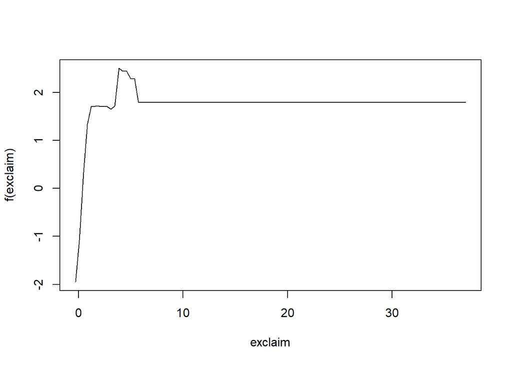

```r
plot(res$model,i="exclaim")
```

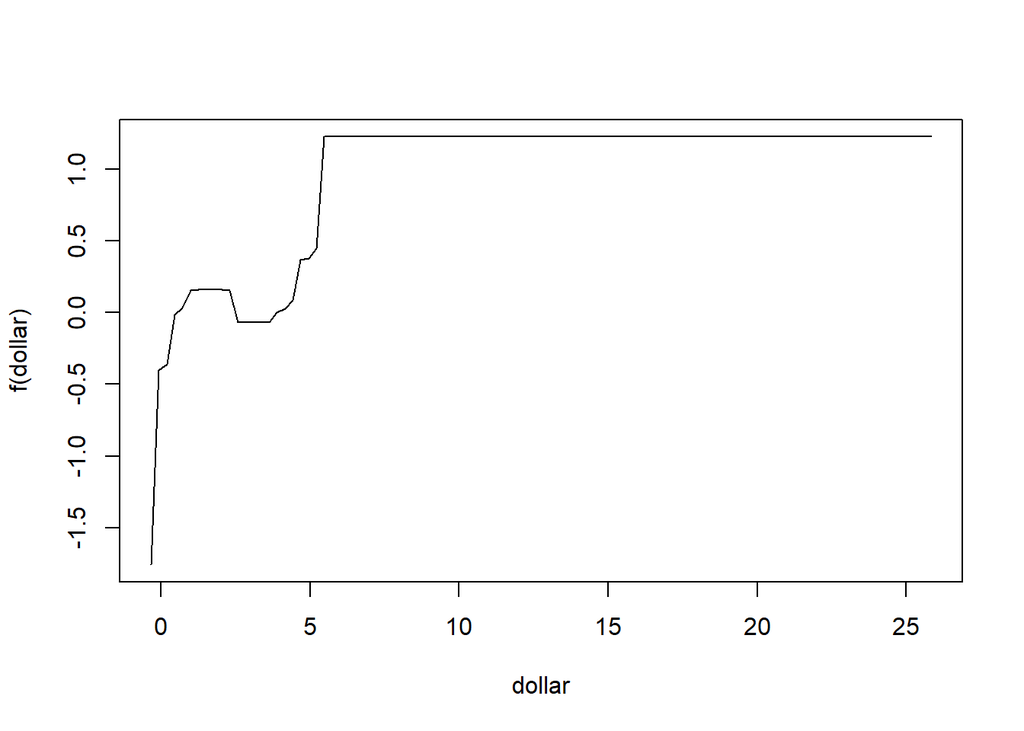

```r
plot(res$model, i = "dollar")
```

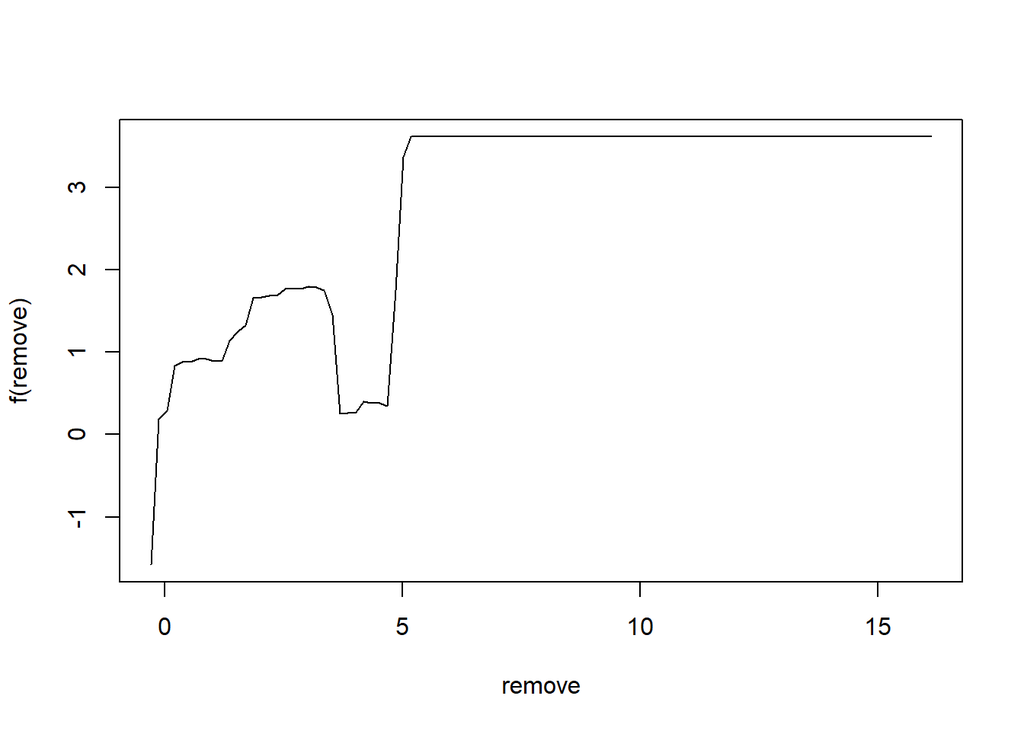

```r
plot(res$model, i = "remove")
```

# Problem 7:

**(15)Regression: California Housing.The data set calif_stats315B.csv consists of aggregated data from 20,640 California census blocks (from the 1990 census). The goal is to predict the median house value in each neighborhood from the others described in calif_stats315B.txt. Fit a gbm model to the data and write a short report that should include at least**

```r
calif <- read.csv("calif_stats315B.csv", header=F)
colnames(calif) <- c("Value", "Income", "Age", "Rooms", "Bedrooms", "Population", "Occupancy", "Latitude", "Longitude")

gbm.calif <- gbm(Value ~ ., data=calif, train.fraction=0.8, interaction.depth=4, shrinkage = 0.05, n.trees=2500, bag.fraction=0.5, cv.folds=5, distribution="gaussian", verbose=T)
```

[output not shown]

[output cut: 120 more lines]

```r
gbm.predict <- predict(gbm.calif, calif[-1])
```

```
## Using 1878 trees...
```

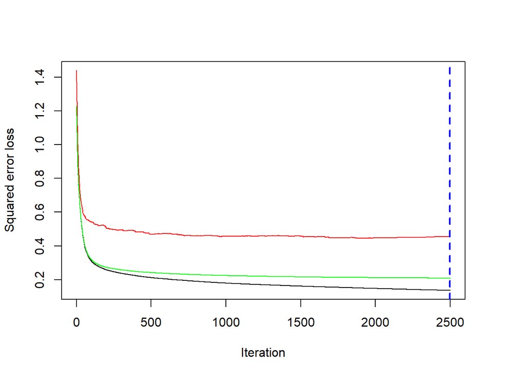

```
## [1] 2497
```

```r
gbm.perf(gbm.calif, method="cv")
```

```r
(MSE <- sum((gbm.predict - calif$Value)**2))
```

```
## [1] 4323.298
```

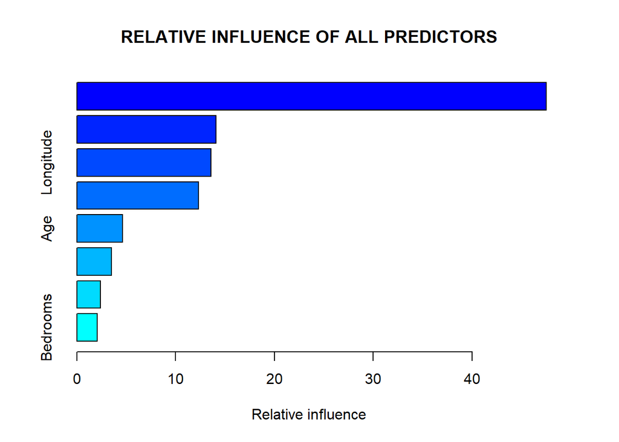

```
##                   var   rel.inf
## Income         Income 47.537024
## Occupancy   Occupancy 14.076729
## Longitude   Longitude 13.558207
## Latitude     Latitude 12.302861
## Age               Age  4.605160
## Rooms           Rooms  3.488832
## Population Population  2.363167
## Bedrooms     Bedrooms  2.068020
```

```r
summary(gbm.calif, main="RELATIVE INFLUENCE OF ALL PREDICTORS")
```

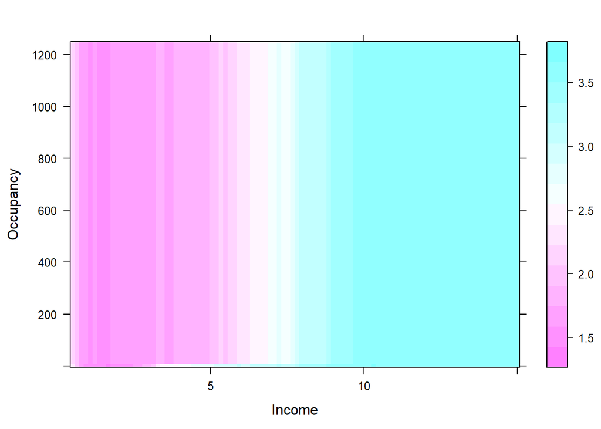

```r
plot(gbm.calif, c(1,6))
```

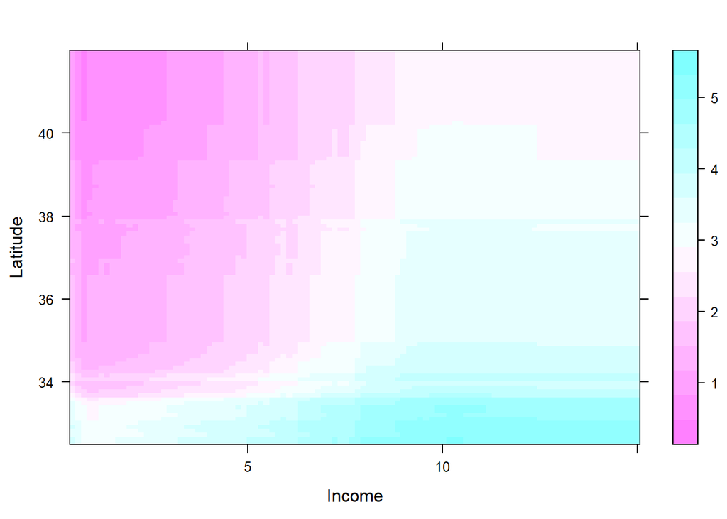

```r
plot(gbm.calif, c(1,7))
```

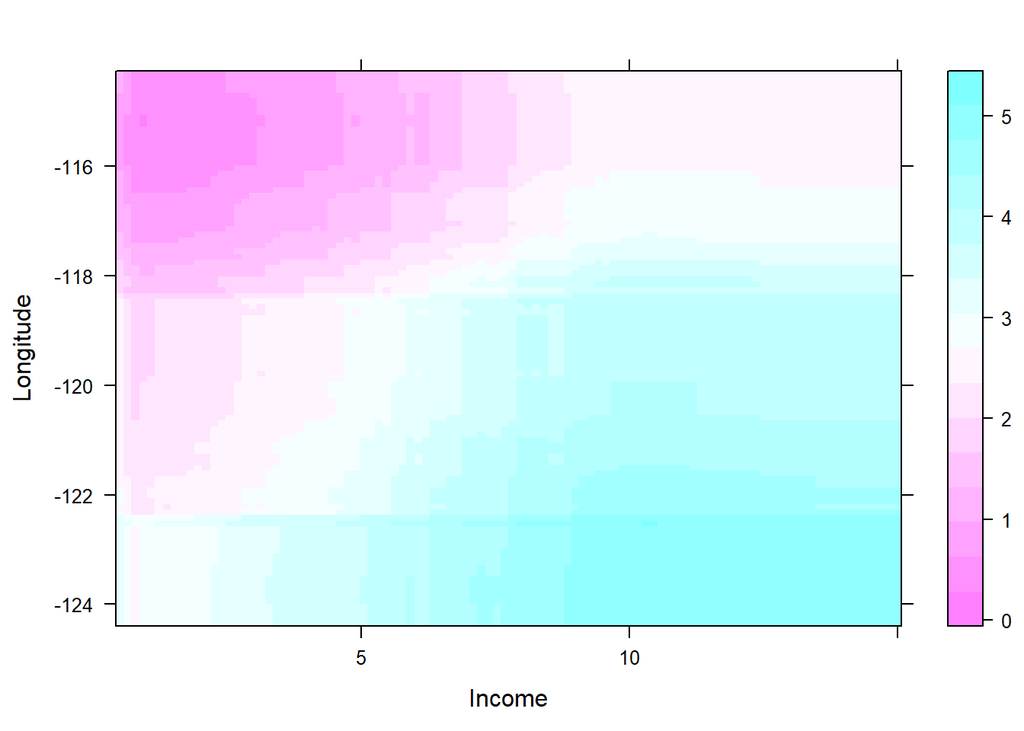

```r
plot(gbm.calif, c(1,8))
```

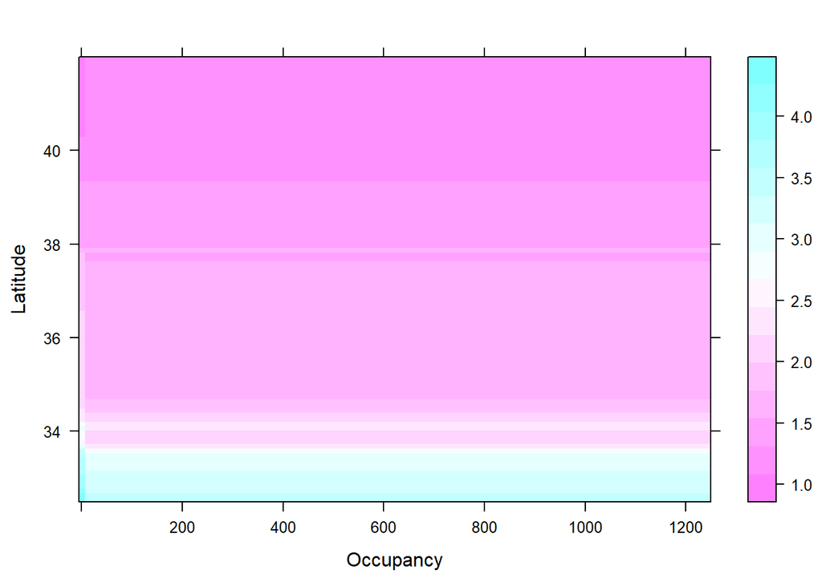

```r
plot(gbm.calif, c(6,7))
```

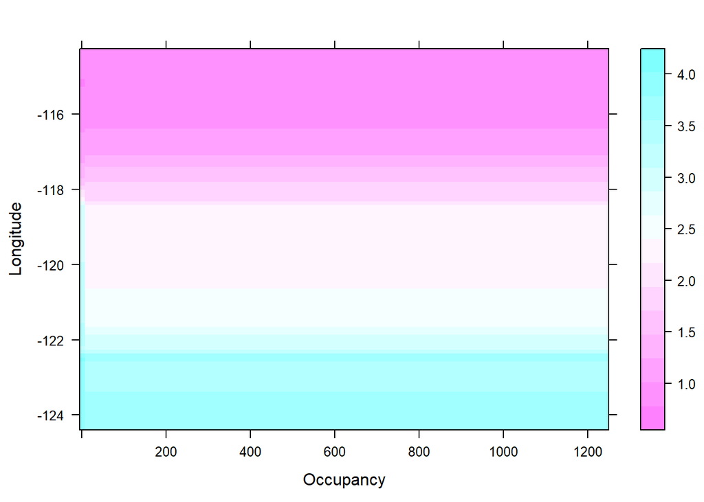

```r
plot(gbm.calif, c(6,8))
```

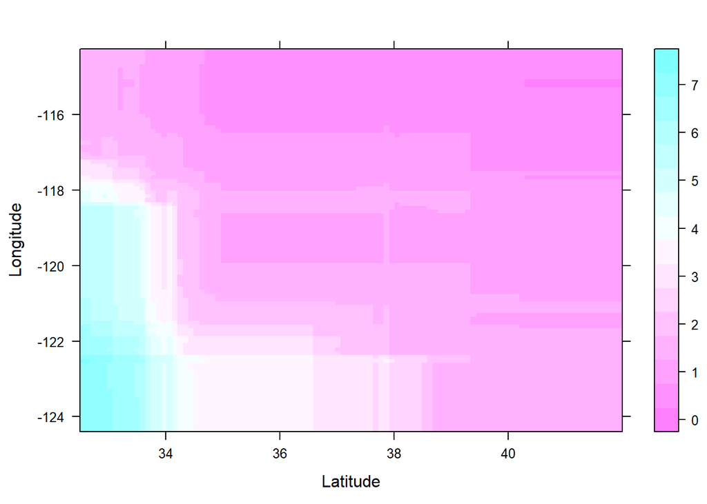

```r
plot(gbm.calif, c(7,8))
```

**(a) The prediction accuracy of gbm on the data set.**

**(b) Identification of the most important variables.**

In order: Income, Occupancy, Longitude, Latitude, Age, Rooms, Population, Bedrooms.

**(c) Comments on the dependence of the response on the most important variables (you maywant to consider partial dependence plots (plot) on single and pairs of variables, etc.).**

In considering potential interactions, we only considered Income, Occupancy, Longitude, and Latitude. Occupancy has no noticable interactions with any of the other 3 big variables. However, all 3 other important variables exhibit a good deal of interaction with one another as shown by the partial dependence plots.

# Problem 8:

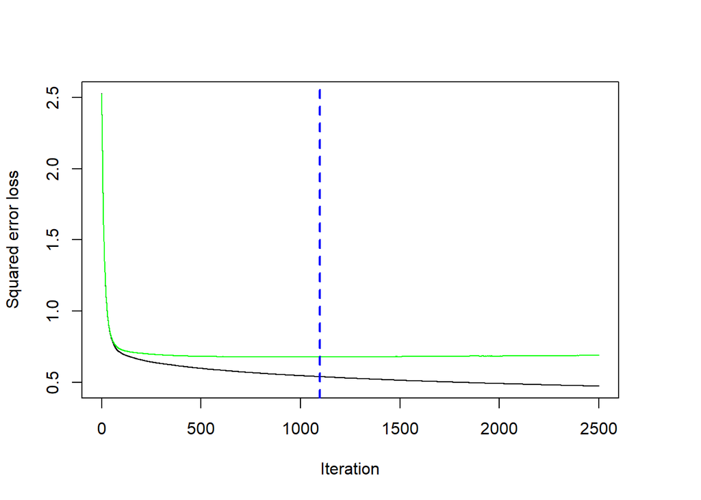

```
## [1] 1097
```

```r
age <- read.csv("age_stats315B.csv", header=T)
factor_columns <- c(2,3,4,5,9,12,13,14)
ordered_columns <- c(1,6,7,8,10,11)
age[, factor_columns] <- lapply(age[factor_columns], as.factor)
age[, ordered_columns] <- lapply(age[ordered_columns], as.ordered)

train_ind <- sample(1:nrow(age), size = nrow(age) * .8)
test_ind <- seq(1,nrow(age))[!(seq(1,nrow(age)) %in% train_ind)]

gbm.age <- gbm(age ~ ., data=age[train_ind,], interaction.depth=4, shrinkage = 0.05, n.trees=2500, bag.fraction=0.5, cv.folds=5, distribution="gaussian", verbose=T)
gbm.perf(gbm.age, method="cv")
```

```r
gbm.predict <- predict(gbm.age, age[test_ind,-1])
```

```
## Using 1097 trees...
```

```r
(acc <- sum(round(gbm.predict) == age[test_ind,]$age)/length(test_ind) )
```

```
## [1] 0.5275545
```

```r
model <- rpart(age ~ ., data = age[train_ind,])
rpart.pred <- predict(model, age[test_ind,-1])
(acc_rpart <- sum(round(rpart.pred) == age[test_ind,]$age)/length(test_ind) )
```

```
## [1] 0.09414466
```

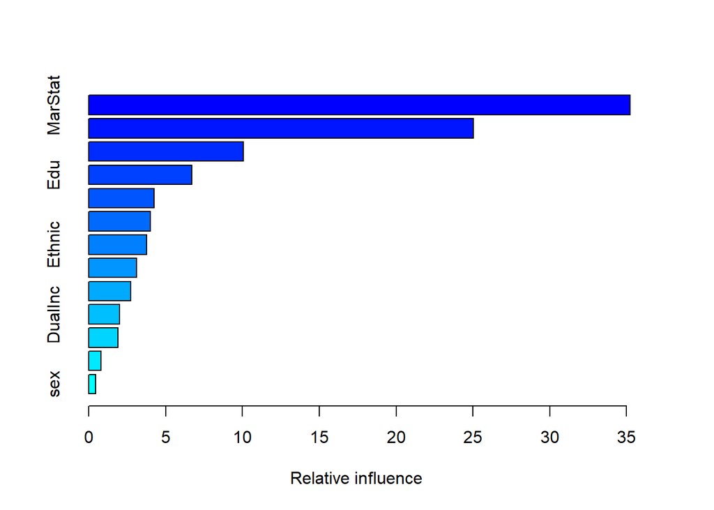

```
##                 var    rel.inf
## MarStat     MarStat 35.2290922
## Occup         Occup 25.0404818
## HouseStat HouseStat 10.0611513
## Edu             Edu  6.6900770
## Income       Income  4.2427596
## Persons     Persons  4.0105836
## Ethnic       Ethnic  3.7657647
## Under18     Under18  3.0947165
## LiveBA       LiveBA  2.7421086
## DualInc     DualInc  1.9986906
## TypeHome   TypeHome  1.8884272
## Lang           Lang  0.7970125
## sex             sex  0.4391344
```

```r
summary(gbm.age)
```

**(15) Regression: Marketing data.The data setage_stats315B.csv was already usedin Homework 1. Reviewage_stats315B.txtfor the information about order of attributes etc.**

**(a) Fit a gbm model for predicting age form the other demographic attributes and compare the accuracy with the accuracy of your best single tree from Homework 1.**

**(b) Identify the most important variables.**

# Problem 9.

```r
occup <- read.csv("occup_stats315B.csv", header=F)
colnames(occup) <- c("Occup", "TypeHome", "sex", "MarStat", "age", "Edu", "Income", "LiveBA", "DualInc", "Persons", "Under18", "HouseStat", "Ethnic", "Lang" )
factor_columns <- c(1,2,3,4,9,12,13,14)
ordered_columns <- c(5,6,7,8,10,11)
occup[, factor_columns] <- lapply(occup[factor_columns], as.factor)
occup[, ordered_columns] <- lapply(occup[ordered_columns], as.ordered)

train_ind <- sample(1:nrow(occup), size = nrow(occup) * .8)
test_ind <- seq(1,nrow(occup))[!(seq(1,nrow(occup)) %in% train_ind)]

### CURRENT THINKING: Make a matrix, store the predicted probabilities for each class, predicting on dummy encodings, then determine the prediction based on which category has the highest probability, calculate accuracy. Not sure how to decide which are the most important variables.... maybe there's some consensus about which are most important for most classes?

#for (i in 1:9) {
#    occup$dummy <- (occup$Occup == i)
#    gbm.occup <- gbm(dummy ~ ., data=occup[train_ind,-1], interaction.depth=4, shrinkage = 0.05, n.trees=2500, bag.fraction=0.5, cv.folds=5, #distribution="bernoulli", verbose=T)
#    gbm.predict <- predict(gbm.occup, type="response", occup[test_ind,c(-1,-15)])
#}

gbm.occup <- gbm(Occup ~ ., data= occup[train_ind,], interaction.depth=4, shrinkage = 0.05, n.trees=2500, bag.fraction=0.5, cv.folds=5, distribution="multinomial", verbose=T)
best_iter = gbm.perf(gbm.occup, method="cv")
```

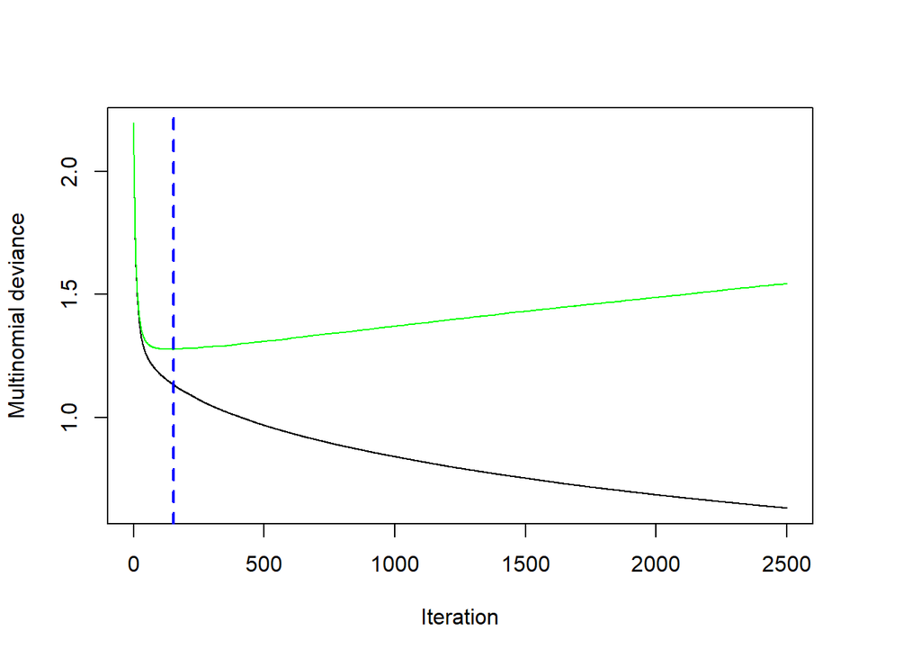

```r
gbm.predict <- predict(gbm.occup, occup[test_ind,-1], type = "response", n.trees = best_iter)
predict_probs <- matrix(unlist(gbm.predict), ncol = 9, byrow = F) #n by classes

class_preds <- apply(predict_probs, 1, function(probs) return(which(probs == max(probs))))
true_class <- occup[test_ind, 1]


misclassification.error <- sum(class_preds != true_class) / length(true_class) * 100
misclass_perclass <- data.frame(1:9)
misclass_perclass$error <- sapply(1:9, function(i) return( sum(class_preds[true_class == i] != i) / sum(true_class == i))) * 100
```

**(15) Multiclass classification: marketing data.The data set occup_stats315B.csvcomes from the same marketing database used in Homework 1. The description of the attributes can be found in occup_stats315B.txt. The goal in this problem is to fit a gbm model to predict the type of occupation from the 13 other demographic variables.**

**(a) Report the test set misclassification error for gbm on the data set, and also the misclassification error for each class.** Misclassification error: 42.0428894

```r
print(misclass_perclass)
```

```
##   X1.9    error
## 1    1 21.96429
## 2    2 92.76316
## 3    3 63.94558
## 4    4 71.23288
## 5    5 41.22137
## 6    6 17.54967
## 7    7 54.34783
## 8    8 28.47222
## 9    9 81.69014
```

**(b) Identify the most important variables.**

```r
imp <- summary(gbm.occup)
```

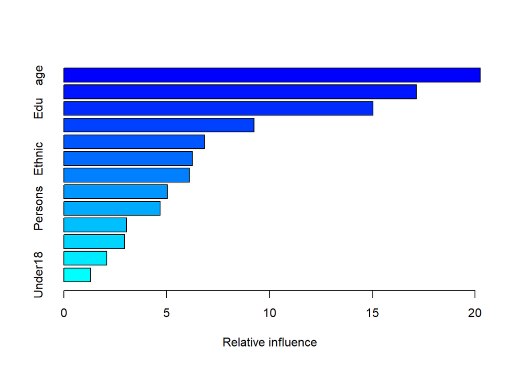

```r
print(imp[1:5, ])
```

```
##                 var   rel.inf
## age             age 20.251226
## Income       Income 17.147167
## Edu             Edu 15.039571
## HouseStat HouseStat  9.248006
## DualInc     DualInc  6.843764
```